# Literacy 201701

coop711

2019-09-12

#### Data

##### 정답과 대조하여 R(Right)/W(Wrong) 표시

| A1 | A2 | A3 | A4 | A5 | A6 | A7 | A8 | A9 | A10 | A11 | A12 | A13 | A14 | A15 | A16 | A17 | A18 | A19 | A20 | A21 | A22 | A23 | A24 | A25 |
| --- | --- | --- | --- | --- | --- | --- | --- | --- | --- | --- | --- | --- | --- | --- | --- | --- | --- | --- | --- | --- | --- | --- | --- | --- |
| R | R | R | R | R | R | R | R | R | R | R | R | R | R | R | R | W | R | R | R | R | R | R | R | R |
| R | R | R | R | R | R | R | R | R | R | R | R | R | R | R | R | R | R | R | R | R | R | R | R | R |
| R | W | R | R | R | R | R | R | R | R | R | W | R | R | R | R | R | R | R | R | R | W | R | R | R |
| R | R | R | R | R | R | R | R | R | R | R | R | R | R | R | R | R | R | R | R | R | W | R | R | R |
| R | R | R | R | W | W | R | W | W | R | R | W | R | R | R | W | W | W | R | W | W | W | R | R | R |
| R | R | R | R | R | R | R | R | W | R | R | W | R | R | R | R | R | R | R | R | R | W | R | R | R |
| R | R | R | R | R | W | R | R | W | R | R | W | R | R | W | R | W | R | R | R | R | R | R | W | R |
| R | R | R | R | R | W | R | W | R | R | R | R | R | R | R | R | R | R | R | R | R | R | R | R | R |
| R | W | R | R | R | R | R | R | W | R | R | W | R | R | R | R | R | R | R | R | R | R | R | R | W |
| R | R | R | R | R | W | R | R | W | R | R | W | R | R | R | R | W | R | R | R | R | R | R | R | R |
| R | R | R | R | R | R | R | R | W | R | R | R | R | R | R | R | R | R | R | R | W | W | R | R | R |
| R | R | R | R | W | W | R | R | W | R | R | W | R | R | R | R | R | R | R | W | R | W | R | W | R |
| R | R | R | R | R | R | R | W | R | R | R | R | R | R | R | R | R | R | R | R | W | W | R | R | R |
| NA | NA | NA | NA | NA | NA | NA | NA | NA | NA | NA | NA | NA | NA | NA | NA | NA | NA | NA | NA | NA | NA | NA | NA | NA |
| R | R | R | R | R | W | R | R | W | R | R | W | R | R | R | R | R | R | R | W | R | W | R | W | R |
| R | R | R | W | W | W | W | W | W | NA | R | W | R | R | R | W | R | R | R | R | R | R | R | R | R |
| R | R | R | R | R | R | R | R | R | R | R | R | R | W | R | R | R | R | R | W | R | W | R | R | W |
| R | R | R | R | R | R | R | R | R | R | R | R | R | W | R | R | R | R | R | W | R | W | R | R | W |
| R | R | R | R | R | R | R | R | R | R | R | R | R | W | R | R | R | R | R | W | R | W | R | R | W |
| R | R | R | R | R | R | R | R | R | R | R | W | R | R | R | W | R | R | R | R | R | R | R | R | R |
| R | R | W | R | R | R | R | R | R | R | R | R | R | R | R | R | R | R | R | R | R | R | R | R | R |
| R | R | R | R | W | R | R | R | R | R | R | W | R | R | R | R | R | R | R | R | R | W | R | R | R |
| R | W | R | R | R | R | R | R | W | R | R | W | R | R | R | R | R | R | R | W | R | R | R | R | R |
| R | R | R | R | R | W | R | R | R | R | R | R | R | R | R | R | R | R | R | R | R | R | R | R | W |
| R | R | R | R | R | R | R | R | R | R | R | R | R | R | R | R | W | R | R | R | R | R | R | R | R |
| R | R | R | R | R | R | R | R | W | R | R | W | W | R | R | R | R | R | R | R | R | R | W | R | R |
| R | R | R | R | R | R | R | R | W | R | W | W | R | R | R | R | R | R | R | R | R | W | R | R | R |
| R | R | R | R | R | R | R | R | R | R | R | W | R | R | R | R | R | R | R | R | R | R | R | R | R |
| R | R | R | R | R | R | R | W | W | W | R | W | R | R | R | R | R | R | R | R | R | R | W | R | R |
| R | R | R | R | R | R | R | R | W | R | R | R | R | R | R | R | R | R | R | R | R | W | R | R | R |

[output cut: 131 more lines]

##### 학생별 점수 산출

*96*, *100*, *88*, *96*, *56*, *88*, *76*, *92*, *84*, *84*, *88*, *72*, *88*, *NA*, *76*, *64*, *84*, *84*, *84*, *92*, *96*, *88*, *84*, *92*, *96*, *84*, *84*, *96*, *80*, *92*, *88*, *88*, *76*, *88*, *100*, *96*, *84*, *92*, *80*, *80*, *84*, *88*, *88*, *76*, *84*, *88*, *72*, *92*, *68*, *100*, *84*, *96*, *NA*, *96*, *96*, *92*, *100*, *88*, *NA*, *92*, *92*, *100*, *88*, *88*, *NA*, *88*, *88*, *88*, *56*, *80*, *88*, *88*, *84*, *96*, *100*, *88*, *92*, *92*, *92*, *92*, *84*, *84*, *100*, *88*, *88*, *92*, *88*, *92*, *80*, *84*, *72*, *96*, *92*, *80*, *68*, *88*, *92*, *72*, *72*, *92*, *76*, *80*, *88*, *92*, *100*, *92*, *92*, *96*, *96*, *92*, *92*, *100*, *96*, *100*, *100*, *92*, *96*, *NA*, *92*, *100*, *NA*, *80*, *88*, *92*, *76*, *68*, *92*, *88*, *96*, *92*, *92*, *88*, *84*, *88*, *92*, *92*, *88*, *88*, *76*, *84*, *100*, *88*, *76*, *88*, *80*, *84*, *72*, *NA*, *76*, *88*, *84*, *68*, *88*, *72*, *80*, *100*, *92*, *84*, *72*, *84* and *96*

##### Red and Black 비교

- **Red**:

  | Min. | 1st Qu. | Median | Mean | 3rd Qu. | Max. | NA’s |
  | --- | --- | --- | --- | --- | --- | --- |
  | 68 | 84 | 88 | 87.35 | 92 | 100 | 1 |

- **Black**:

  | Min. | 1st Qu. | Median | Mean | 3rd Qu. | Max. | NA’s |
  | --- | --- | --- | --- | --- | --- | --- |
  | 56 | 84 | 88 | 86.81 | 92 | 100 | 6 |

```
##
##   The decimal point is 1 digit(s) to the right of the |
##
##    5 | 66
##    6 | 4
##    6 | 8888
##    7 | 22222222
##    7 | 666666666
##    8 | 00000000004444444444444444444444
##    8 | 88888888888888888888888888888888888
##    9 | 22222222222222222222222222222222
##    9 | 66666666666666666
##   10 | 00000000000000
```

- Red

```r
stem(literacy.score[Red], scale = 0.5)
```

```
##
##   The decimal point is 1 digit(s) to the right of the |
##
##    6 | 888
##    7 | 222666666
##    8 | 000000044444444444448888888888888888
##    9 | 222222222222266666666666
##   10 | 00000000
```

- Black

```r
stem(literacy.score[Black], scale = 0.5)
```

```
##
##   The decimal point is 1 digit(s) to the right of the |
##
##    5 | 66
##    6 | 48
##    7 | 22222666
##    8 | 0004444444448888888888888888888
##    9 | 2222222222222222222666666
##   10 | 000000
```

##### Box Plots

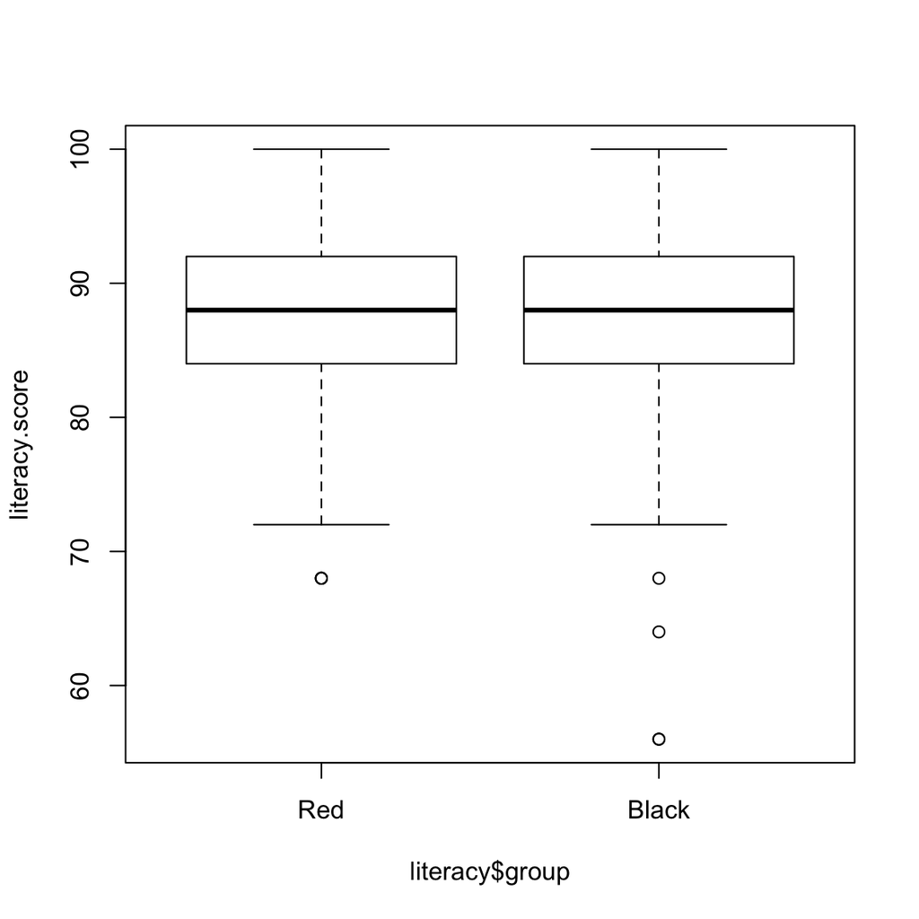

##### QQ plot

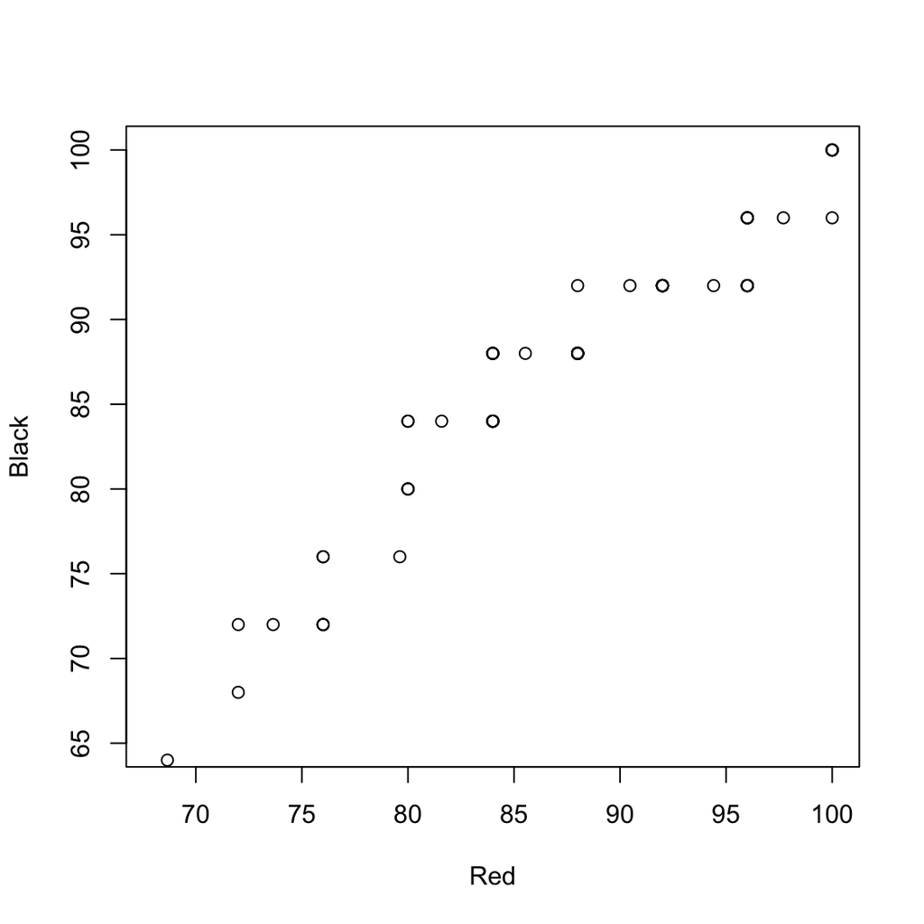

##### ECDF plot

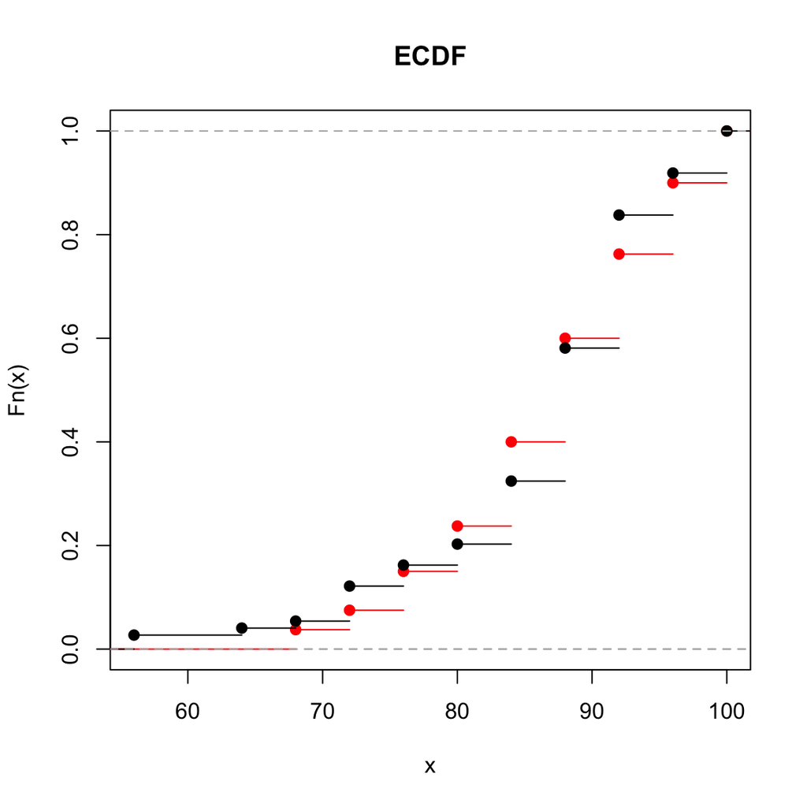

##### 문해력 등급 판정

- I수준(24점 이하), II수준(28 ~ 48점), III수준(52 ~ 72점), IV수준(76점 이상)

문해력 등급 분포

| I | II | III | IV | 결석 |
| --- | --- | --- | --- | --- |
| 0 | 0 | 15 | 139 | 7 |

그룹별 문해력 등급 분포

|  | I | II | III | IV | 결석 |
| --- | --- | --- | --- | --- | --- |
| **Red** | 0 | 0 | 6 | 74 | 1 |
| **Black** | 0 | 0 | 9 | 65 | 6 |

#### 문항 유형별 점수 분석

##### 유형별 정답률

|  | 유형 | 정답률 |
| --- | --- | --- |
| **문1** | 사실적 | 99.4 |
| **문2** | 사실적 | 91.6 |
| **문3** | 비판적 | 89.6 |
| **문4** | 사실적 | 94.8 |
| **문5** | 추론적 | 89.6 |
| **문6** | 추론적 | 76.0 |
| **문7** | 추론적 | 99.4 |
| **문8** | 사실적 | 84.4 |
| **문9** | 추론적 | 54.5 |
| **문10** | 추론적 | 96.1 |
| **문11** | 사실적 | 97.4 |
| **문12** | 사실적 | 52.6 |
| **문13** | 사실적 | 94.2 |
| **문14** | 추론적 | 96.1 |
| **문15** | 사실적 | 81.8 |
| **문16** | 사실적 | 93.5 |
| **문17** | 추론적 | 71.4 |
| **문18** | 비판적 | 96.1 |
| **문19** | 사실적 | 99.4 |
| **문20** | 사실적 | 88.3 |
| **문21** | 사실적 | 89.6 |
| **문22** | 비판적 | 66.2 |
| **문23** | 추론적 | 96.1 |
| **문24** | 사실적 | 91.6 |
| **문25** | 추론적 | 87.7 |

#### 어려운 문제?

##### 정답률 80% 이하

| 문6 | 문9 | 문12 | 문17 | 문22 |
| --- | --- | --- | --- | --- |
| 75.97 | 54.55 | 52.6 | 71.43 | 66.23 |

##### 정답률 70% 이하

| 문9 | 문12 | 문22 |
| --- | --- | --- |
| 54.55 | 52.6 | 66.23 |

##### 정답률 60% 이하

|  | 문9 | 문12 |
| --- | --- | --- |
| **정답률** | 54.55 | 52.6 |